# HW7

d - The posterior histograms show that explicit, artist_pop, and the intercept have noticeable impact since their weights are far from zero. Weights close to zero, such as for release_year, suggest that these features may not significantly influence track popularity.

e - i. The predicted versus actual plot shows a clear positive trend, suggesting that the model captures general patterns in the data even if it misses some individual points. ii. The correlation between predictions and true values is 0.7, indicating a moderately strong predictive performance. iii. The model does a fairly good job predicting track popularity, capturing key trends and providing useful estimates.

```r
library(brms)
library(tidyverse)
# part 2a

# Reconstruct training data as a data frame for brm
spotify_train <- data.frame(y = y_train, X_train)
colnames(spotify_train)[1] <- "track_pop"

# Define the formula
formula <- bf(track_pop ~ release_month + release_year + artist_pop + duration_s + explicit)

# Use default priors
prior <- default_prior(formula, data = spotify_train, family = gaussian())

# Fit Bayesian linear regression using brm
fit_brm <- brm(
  formula = formula,
  data = spotify_train,
  family = gaussian(),
  chains = 4,
  iter = 10000,
  warmup = 1800,
  prior = prior,
  seed = 42
)
```

```
## Trying to compile a simple C file
```

[output not shown]

```r
# part 2b
summary(fit_brm)
```

```
##  Family: gaussian
##   Links: mu = identity; sigma = identity
## Formula: track_pop ~ release_month + release_year + artist_pop + duration_s + explicit
##    Data: spotify_train (Number of observations: 125)
##   Draws: 4 chains, each with iter = 10000; warmup = 1800; thin = 1;
##          total post-warmup draws = 32800
##
## Regression Coefficients:
##               Estimate Est.Error l-95% CI u-95% CI Rhat Bulk_ESS Tail_ESS
## Intercept        62.38      1.49    59.47    65.29 1.00    48644    25583
## release_month     1.03      1.33    -1.60     3.60 1.00    49728    25631
## release_year     -0.57      1.33    -3.17     2.04 1.00    46926    25799
## artist_pop       11.60      1.36     8.96    14.28 1.00    48798    27266
## duration_s       -0.62      1.44    -3.44     2.20 1.00    45151    25701
## explicit         -4.32      3.45   -11.18     2.46 1.00    46004    25856
##
## Further Distributional Parameters:
##       Estimate Est.Error l-95% CI u-95% CI Rhat Bulk_ESS Tail_ESS
## sigma    14.70      0.96    12.96    16.72 1.00    44547    25337
##
## Draws were sampled using sampling(NUTS). For each parameter, Bulk_ESS
## and Tail_ESS are effective sample size measures, and Rhat is the potential
## scale reduction factor on split chains (at convergence, Rhat = 1).
```

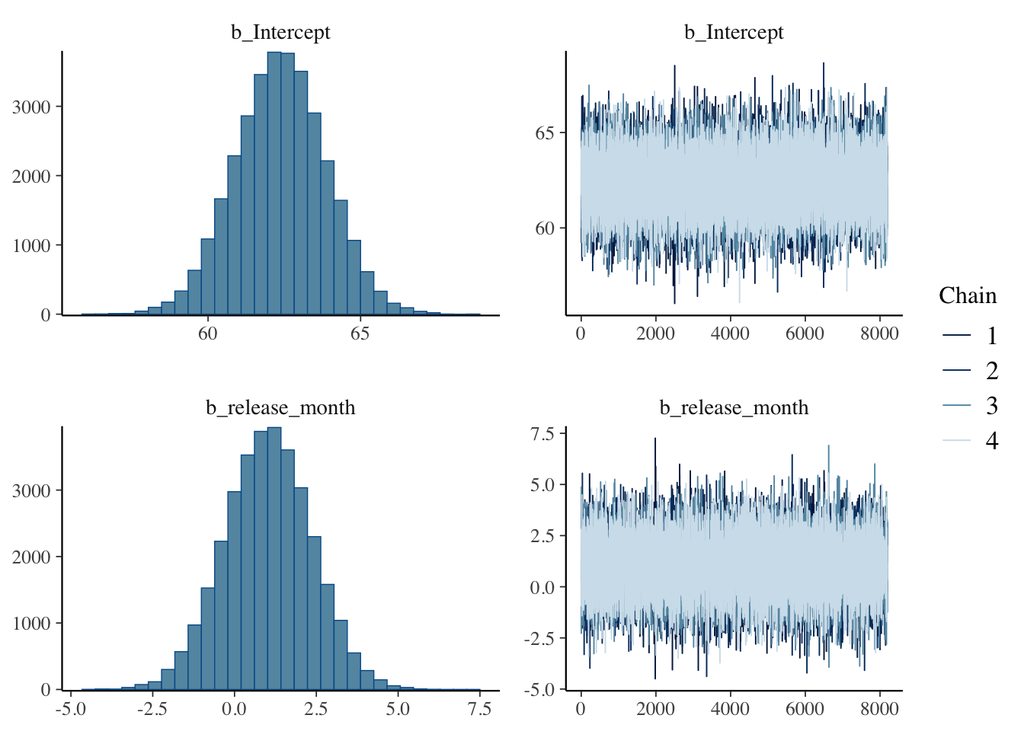

```r
plot(fit_brm, variable = c("b_Intercept", "b_release_month"))
```

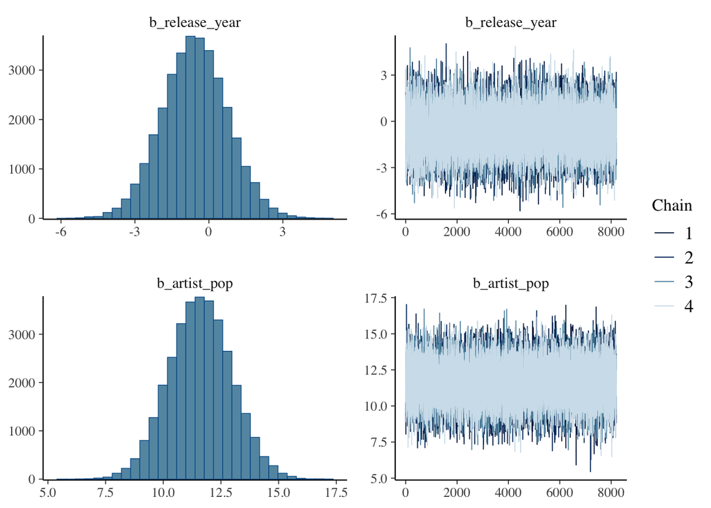

```r
plot(fit_brm, variable = c("b_release_year", "b_artist_pop"))
```

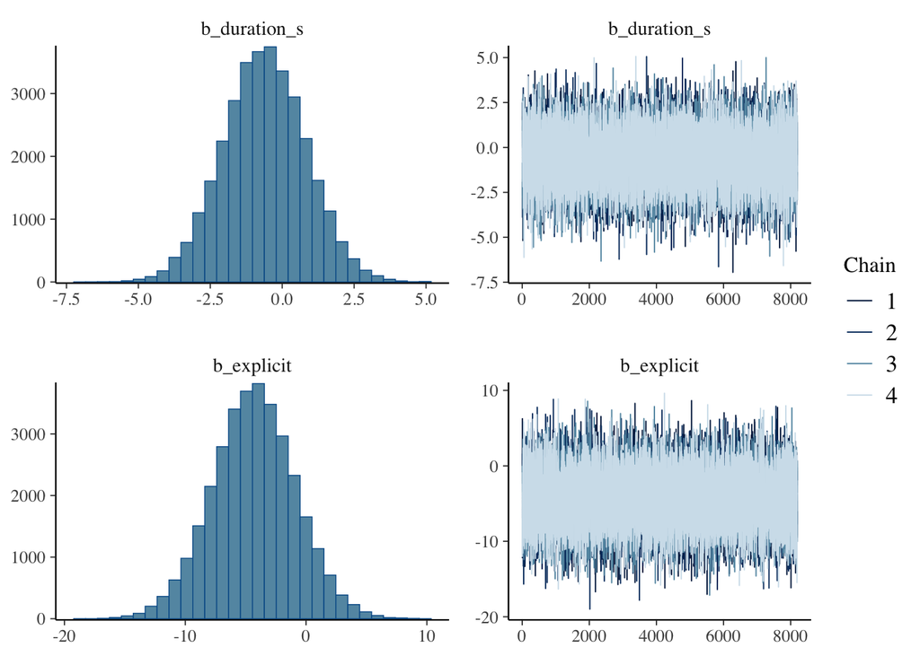

```r
plot(fit_brm, variable = c("b_duration_s", "b_explicit"))
```

```r
# plot(fit_brm) # doesnt run
```

```r
bayes_R2(fit_brm)
```

```
##     Estimate  Est.Error      Q2.5     Q97.5
## R2 0.3939381 0.05160054 0.2845221 0.4851236
```

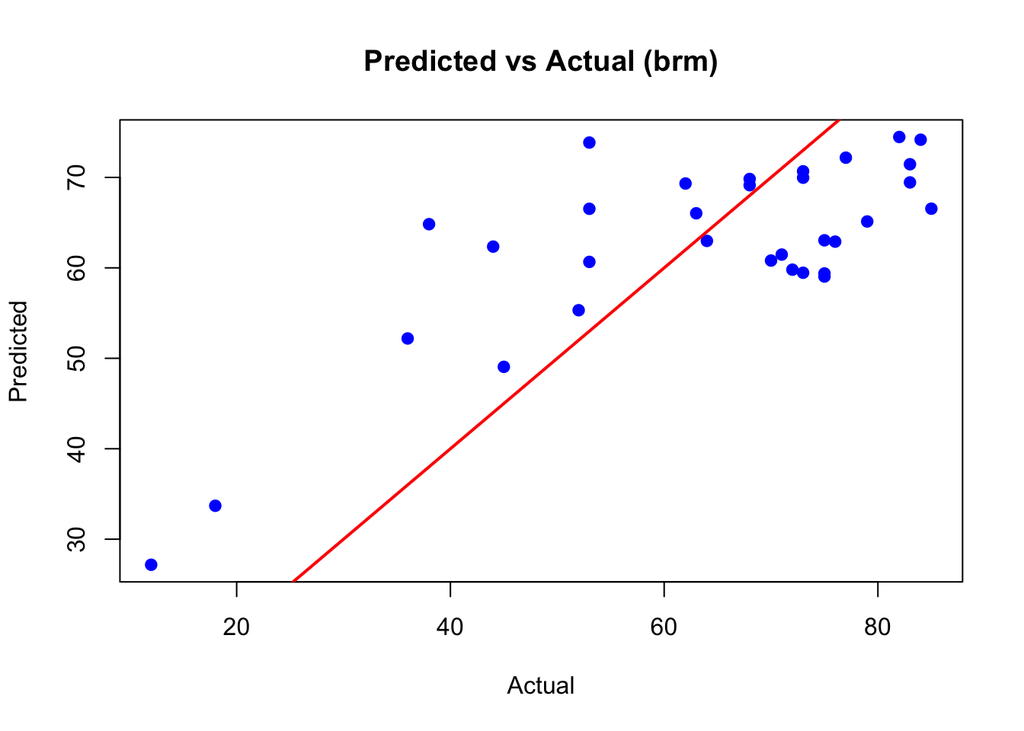

```r
spotify$track_pop <- y
spotify$intercept <- NULL
spotify_train <- spotify[train_idx, ]
spotify_test <- spotify[-train_idx, ]

# newdata = spotify_test
post_preds_brm <- posterior_predict(fit_brm, newdata = spotify_test)

# Take the mean of posterior predictions for each observation
pred_means_brm <- colMeans(post_preds_brm)

#  predicted vs actual
plot(y_test, pred_means_brm, main = "Predicted vs Actual (brm)",
     xlab = "Actual", ylab = "Predicted", pch = 19, col = "blue")
abline(a = 0, b = 1, col = "red", lwd = 2)
```

```r
# Correlation
cor(y_test, pred_means_brm)
```

```
## [1] 0.7651451
```

```r
# Scale
spotify$track_pop_scaled <- spotify$track_pop / 100
spotify_train <- spotify[train_idx, ]
spotify_test <- spotify[-train_idx, ]

prior_beta <- default_prior(track_pop_scaled ~ release_month + release_year + artist_pop + duration_s + explicit,
                            data = spotify_train,
                            family = Beta())
# beta regression
fit_beta <- brm(track_pop_scaled ~ release_month + release_year + artist_pop + duration_s + explicit,
                data = spotify_train,
                family = Beta(),
                prior = prior_beta,
                chains = 4,
                iter = 10000,
                warmup = 1800,
                seed = 42)
```

```
## Trying to compile a simple C file
```

[output not shown]

```r
summary(fit_beta)
```

```
##  Family: beta
##   Links: mu = logit; phi = identity
## Formula: track_pop_scaled ~ release_month + release_year + artist_pop + duration_s + explicit
##    Data: spotify_train (Number of observations: 125)
##   Draws: 4 chains, each with iter = 10000; warmup = 1800; thin = 1;
##          total post-warmup draws = 32800
##
## Regression Coefficients:
##               Estimate Est.Error l-95% CI u-95% CI Rhat Bulk_ESS Tail_ESS
## Intercept         0.52      0.07     0.39     0.65 1.00    43846    23069
## release_month     0.05      0.06    -0.06     0.17 1.00    48122    25557
## release_year     -0.01      0.06    -0.13     0.10 1.00    43399    27013
## artist_pop        0.52      0.06     0.39     0.65 1.00    43919    26337
## duration_s       -0.04      0.07    -0.17     0.09 1.00    44339    27090
## explicit         -0.23      0.15    -0.53     0.08 1.00    41619    25585
##
## Further Distributional Parameters:
##     Estimate Est.Error l-95% CI u-95% CI Rhat Bulk_ESS Tail_ESS
## phi     9.33      1.14     7.24    11.71 1.00    42441    25710
##
## Draws were sampled using sampling(NUTS). For each parameter, Bulk_ESS
## and Tail_ESS are effective sample size measures, and Rhat is the potential
## scale reduction factor on split chains (at convergence, Rhat = 1).
```

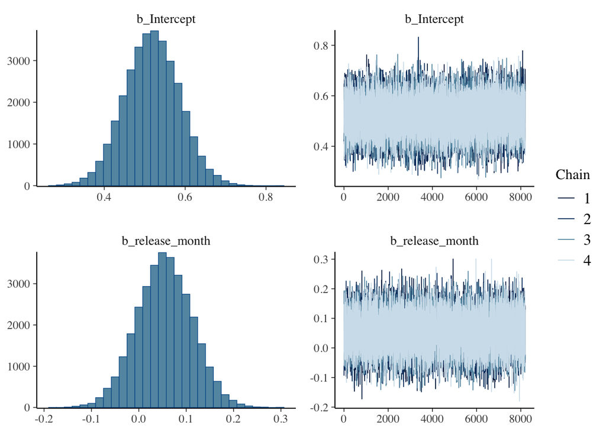

```r
plot(fit_beta, variable = c("b_Intercept", "b_release_month"))
```

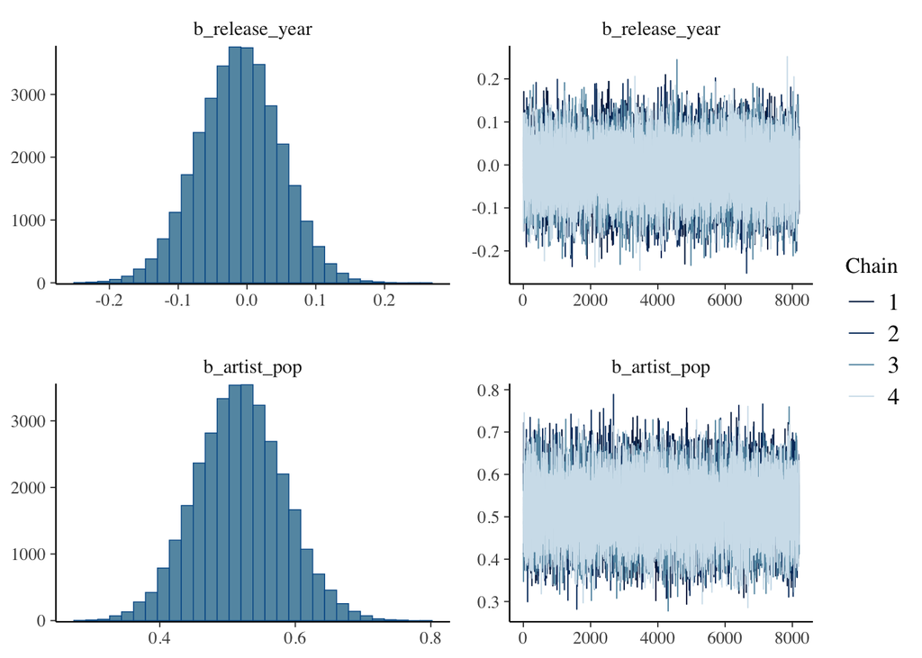

```r
plot(fit_beta, variable = c("b_release_year", "b_artist_pop"))
```

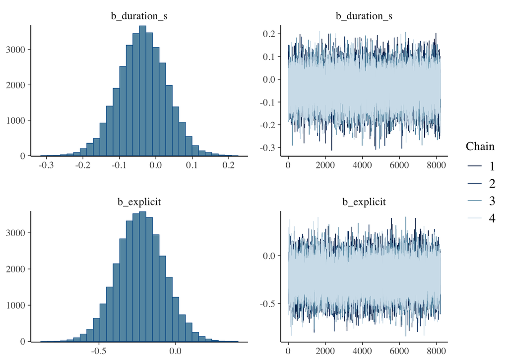

```r
plot(fit_beta, variable = c("b_duration_s", "b_explicit"))
```

```r
bayes_R2(fit_beta)
```

```
##    Estimate  Est.Error      Q2.5     Q97.5
## R2 0.405988 0.04891394 0.2997096 0.4906092
```